# Database System

Final Exam

Group 1

May 27, 2021

[figure not shown]

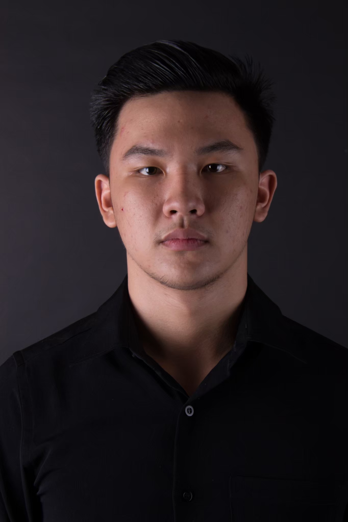

Email : juliansalomo2@gmail.com  
RPubs : https://rpubs.com/juliansalomo/  
Department : [Business Statistics](https://matanauniversity.ac.id/?ly=academic&c=sb)  
Address : ARA Center, Matana University Tower  
Jl. CBD Barat Kav, RT.1, Curug Sangereng, Kelapa Dua, Tangerang, Banten 15810.

Berikut merupakan library-library yang akan digunakan dalam pemodelan spasial

```r
library(rgdal)            # untuk membuka file format .sdh (peta)
library(raster)
library(openxlsx)         # untuk membuka file excel
library(spdep)
library(sp)
library(raster)
library(rgeos)
library(rspatial)
library(latticeExtra)
library(RColorBrewer)
library(spatialreg)
library(DT)
```

# 1 Input Data

Disini saya akan memberikan contoh menggunakan data kemiskinan di Jawa Barat yang dapat di download di link [ini](https://github.com/juliansalomo/jabar) Pertama kita membaca file data lengkap beserta peta Jawa Barat dengan fungsi berikut

```r
data.jabar = read.xlsx("Jabar Data (gabung).xlsx")
jabar2 <- readOGR(dsn = "petaJabar2" , layer = "Jabar2")
datatable(data.jabar, htmltools::em('Table data'),
          extension = 'FixedColumns',
          options = list(scrollX = TRUE, fixedColums = TRUE))
```

|  | PROVNO | KABKOTNO | KODE2010 | PROVINSI | KABKOT | IDSP2010 | Long | Lat | p.miskin15 | p.miskin16 | j.miskin15 | j.miskin16 | AHH2015 | AHH2016 | EYS2015 | EYS2016 | MYS2015 | MYS2016 | EXP2015 | EXP2016 | APM.SD15 | APM.SMP15 | APM.SMA15 | APM.PT15 | APK.SD15 | APK.SMP15 | APK.SMA15 | APK.PT15 | APS.USIA15 | … |
| --- | --- | --- | --- | --- | --- | --- | --- | --- | --- | --- | --- | --- | --- | --- | --- | --- | --- | --- | --- | --- | --- | --- | --- | --- | --- | --- | --- | --- | --- | --- |
| 1 | 32 | 1 | 3201 | JAWA BARAT | BOGOR | 3201 | 106.7687 | -6.561184 | 8.95975943480113 | 8.83457407442807 | 487.1 | 490.8 | 70.59 | 70.65 | 11.83 | 12.05 | 7.75 | 7.83 | 9368 | 9537 | 96.2936375128651 | 72.9705328225212 | 55.1008849913172 | 11.8351861398419 | 108.819486078109 | 84.6324795930733 | 67.9329092825106 | 12.6365476393732 | 99.0486149196668 | … |
| 2 | 32 | 2 | 3202 | JAWA BARAT | SUKABUMI | 3202 | 106.7101 | -7.074623 | 8.96036135967743 | 8.13484799514235 | 217.86 | 198.66 | 70.03 | 70.14 | 12.13 | 12.18 | 6.51 | 6.74 | 7849 | 8077 | 99.6528476442911 | 75.7633979029571 | 43.9354680121258 | 9.92434991853825 | 113.055431476113 | 82.9980356791991 | 54.9365030645984 | 10.4456958321512 | 99.6528476442911 | … |
| 3 | 32 | 3 | 3203 | JAWA BARAT | CIANJUR | 3203 | 107.1578 | -7.133713 | 12.2141601356727 | 11.6214737215477 | 273.9 | 261.39 | 69.28 | 69.39 | 11.83 | 11.88 | 6.54 | 6.61 | 6877 | 7074 | 99.8869556207545 | 78.4031488131515 | 37.180058451971 | 3.86286323081733 | 109.496323662807 | 86.038159410257 | 43.8650071197958 | 4.12295639679323 | 100 | … |
| 4 | 32 | 4 | 3204 | JAWA BARAT | BANDUNG | 3204 | 107.6108 | -7.099969 | 7.99818404121617 | 7.61329293452065 | 281.04 | 272.65 | 73.07 | 73.1 | 12.13 | 12.42 | 8.41 | 8.5 | 9375 | 9580 | 98.0036700532541 | 82.1354033251947 | 55.492162454325 | 17.0426981263269 | 110.039551639979 | 89.6348633375255 | 66.2041671265239 | 19.7369553205003 | 99.9144000267931 | … |
| 5 | 32 | 5 | 3205 | JAWA BARAT | GARUT | 3205 | 107.7889 | -7.359586 | 12.8058075863325 | 11.6403700973255 | 325.67 | 298.52 | 70.69 | 70.76 | 11.65 | 11.69 | 6.84 | 6.88 | 6875 | 7079 | 98.0933357893913 | 75.2808138841888 | 44.6024315883327 | 5.70865933822894 | 111.721234080858 | 82.1663609380028 | 51.5261543084223 | 6.16887183454384 | 98.7783906483622 | … |
| 6 | 32 | 6 | 3206 | JAWA BARAT | TASIKMALAYA | 3206 | 108.1413 | -7.496892 | 11.9944551981029 | 11.2371847644666 | 208.12 | 195.61 | 68.36 | 68.54 | 12.44 | 12.46 | 6.88 | 6.94 | 6934 | 7081 | 99.0865614302367 | 76.9762054764093 | 54.7995361064239 | 12.1581043740394 | 107.091349863626 | 91.7434660745265 | 65.1056805391229 | 13.0119880954752 | 99.789704901448 | … |
| 7 | 32 | 7 | 3207 | JAWA BARAT | CIAMIS | 3207 | 108.4661 | -7.434347 | 8.9822787608304 | 8.41549997737182 | 104.87 | 98.77 | 70.74 | 70.9 | 13.59 | 13.65 | 7.45 | 7.55 | 8296 | 8432 | 99.747927207014 | 78.1905270079679 | 63.3880622469765 | 15.9454251971619 | 108.326854299735 | 84.0125313655112 | 75.2276465891145 | 16.4726870364455 | 100 | … |
| 8 | 32 | 8 | 3208 | JAWA BARAT | KUNINGAN | 3208 | 108.5603 | -7.004233 | 13.9683942456667 | 13.5878513773157 | 147.21 | 144.07 | 72.64 | 72.76 | 12.03 | 12.04 | 7.2 | 7.34 | 8516 | 8580 | 100 | 81.5770754053209 | 61.441463925539 | 11.8589074033984 | 108.651705401513 | 86.2420108152532 | 72.8775659731861 | 13.9932673676697 | 100 | … |
| 9 | 32 | 9 | 3209 | JAWA BARAT | CIREBON | 3209 | 108.5513 | -6.745512 | 14.7743257785355 | 13.4877113095136 | 313.21 | 288.49 | 71.38 | 71.43 | 11.79 | 12.03 | 6.32 | 6.41 | 9261 | 9463 | 94.8186833677305 | 78.406516611354 | 57.1813097651971 | 9.00066719985398 | 104.896393709655 | 91.5808640108344 | 74.32425408308 | 9.56109758645594 | 98.7614933355595 | … |
| 10 | 32 | 10 | 3210 | JAWA BARAT | MAJALENGKA | 3210 | 108.2578 | -6.815865 | 14.1875879570026 | 12.8523652476454 | 167.5 | 152.5 | 69.06 | 69.22 | 11.74 | 11.89 | 6.8 | 6.89 | 8477 | 8594 | 97.0952818983587 | 82.4228045015533 | 48.6813747403545 | 10.4905827170957 | 109.773438484118 | 97.1373154847314 | 60.6891105453009 | 11.8430724510086 | 100 | … |

[output cut: 16 more lines]

# 2 Plot peta data

Sekarang kita akan memvisualisasikan kemiskinan di tahun 2016 di provinsi Jawa Barat. Kemiskinan dari dataset `data.jabar` berada di kolom *p.miskin16*. Kita akan menambahkan kolom ini ke dalam dataset `jabar2` dengan script berikut

```r
jabar2$miskin2<- data.jabar$p.miskin16
```

Selanjutnya kita akan memvisualisasikannya dengan package `sp` dengan fungsi berikut

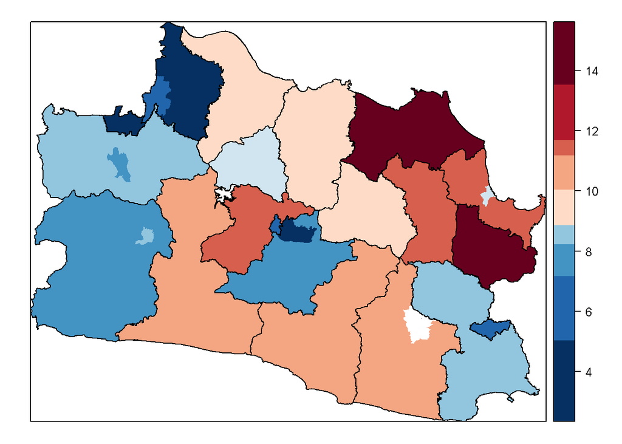

```r
kota <- aggregate(jabar2, "KABKOT")
grps <- 10           #mengelompokkan menjadi 10 interval
brks <- quantile(jabar2$miskin2, 0:(grps-1)/(grps-1), na.rm=TRUE)
p <- spplot(jabar2, "miskin2", at=brks, col.regions=rev(brewer.pal(grps, "RdBu")), col="transparent" )
p + layer(sp.polygons(kota))
```

Dengan plot di atas kita bisa melihat wilayah-wilayah yang terkonsentrasi dengan kemiskinan. Dan kita bisa lihat bahwa di bagian yang merah pekat, area sekitarnya pun memiliki tingkat kemiskinan yang cukup tinggi.

# 3 Pemodelan Regresi Spasial

Di bagian sini kita akan membangun model linier untuk data kita. Model spasial secara global terdiri dari:

- SEM: $y=XB+u$
- SAR: $y=\rho Wy+XB+\varepsilon$
- SARMA: $y=\rho Wy+XB+u$

## 3.1 Model SEM

```r
w<-poly2nb(jabar2)
sem<-errorsarlm(p.miskin16~EYS2016,data=data.jabar,nb2listw(w))
summary(sem)
```

```
##
## Call:errorsarlm(formula = p.miskin16 ~ EYS2016, data = data.jabar,
##     listw = nb2listw(w))
##
## Residuals:
##      Min       1Q   Median       3Q      Max
## -4.24699 -1.36122 -0.13809  1.15579  7.03019
##
## Type: error
## Coefficients: (asymptotic standard errors)
##             Estimate Std. Error z value  Pr(>|z|)
## (Intercept) 36.88515    7.80246  4.7274 2.274e-06
## EYS2016     -2.17498    0.60042 -3.6224 0.0002919
##
## Lambda: 0.61793, LR test value: 8.7676, p-value: 0.0030663
## Asymptotic standard error: 0.1576
##     z-value: 3.9208, p-value: 8.8267e-05
## Wald statistic: 15.372, p-value: 8.8267e-05
##
## Log likelihood: -58.12466 for error model
## ML residual variance (sigma squared): 4.5459, (sigma: 2.1321)
## Number of observations: 26
## Number of parameters estimated: 4
## AIC: 124.25, (AIC for lm: 131.02)
```

## 3.2 Model SAR

```r
sar<-lagsarlm(p.miskin16~EYS2016,data=data.jabar,nb2listw(w))
summary(sar)
```

```
##
## Call:
## lagsarlm(formula = p.miskin16 ~ EYS2016, data = data.jabar, listw = nb2listw(w))
##
## Residuals:
##      Min       1Q   Median       3Q      Max
## -4.17670 -0.93185 -0.11318  0.91353  7.69131
##
## Type: lag
## Coefficients: (asymptotic standard errors)
##             Estimate Std. Error z value  Pr(>|z|)
## (Intercept) 28.22898    7.66250  3.6840 0.0002296
## EYS2016     -1.94997    0.57325 -3.4016 0.0006700
##
## Rho: 0.59078, LR test value: 7.9343, p-value: 0.0048507
## Asymptotic standard error: 0.1559
##     z-value: 3.7894, p-value: 0.00015101
## Wald statistic: 14.36, p-value: 0.00015101
##
## Log likelihood: -58.54132 for lag model
## ML residual variance (sigma squared): 4.7513, (sigma: 2.1798)
## Number of observations: 26
## Number of parameters estimated: 4
## AIC: 125.08, (AIC for lm: 131.02)
## LM test for residual autocorrelation
## test value: 0.036687, p-value: 0.8481
```

## 3.3 Model SARMA

```r
gsm<-sacsarlm(p.miskin16~EYS2016,data=data.jabar,nb2listw(w))
summary(gsm)
```

```
##
## Call:
## sacsarlm(formula = p.miskin16 ~ EYS2016, data = data.jabar, listw = nb2listw(w))
##
## Residuals:
##     Min      1Q  Median      3Q     Max
## -4.0817 -1.2815 -0.1627  1.1317  6.7128
##
## Type: sac
## Coefficients: (asymptotic standard errors)
##             Estimate Std. Error z value  Pr(>|z|)
## (Intercept) 38.02312    8.19667  4.6388 3.504e-06
## EYS2016     -2.15311    0.59378 -3.6261 0.0002877
##
## Rho: -0.14689
## Asymptotic standard error: 0.38983
##     z-value: -0.3768, p-value: 0.70633
## Lambda: 0.69352
## Asymptotic standard error: 0.23014
##     z-value: 3.0135, p-value: 0.0025829
##
## LR test value: 8.8931, p-value: 0.011719
##
## Log likelihood: -58.06189 for sac model
## ML residual variance (sigma squared): 4.3254, (sigma: 2.0797)
## Number of observations: 26
## Number of parameters estimated: 5
## AIC: 126.12, (AIC for lm: 131.02)
```